# COVID Wastewater Surveillance for Western Massachusetts

Updates on Thursday evening, as long as new data is uploaded to the state dashboard (link below).

Regional Concentration and Wastewater Viral Activity Level

```
From 2024-12-12 to 2025-12-11
Current WVA level: High
Current WVA score: 5.6
```

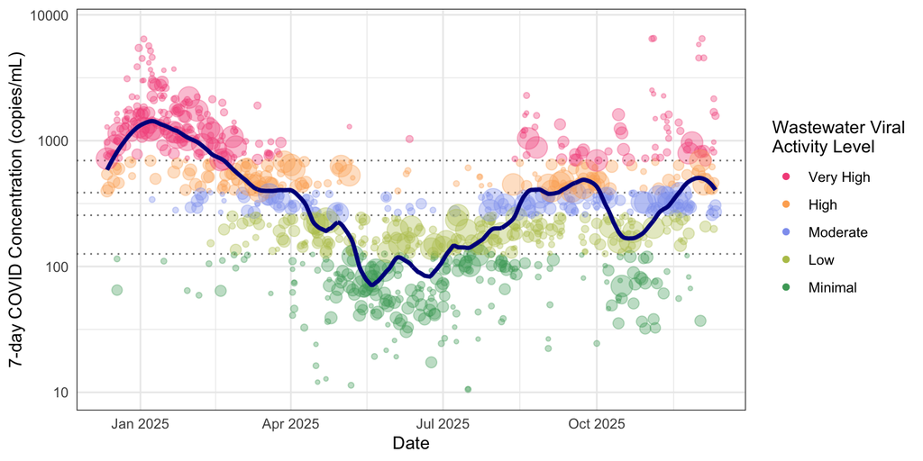

The above figure shows the regional wastewater COVID concentration and Wastewater Viral Activity level (WVA) for 9 sewer systems in Berkshire, Hampden, Hampshire, and Franklin counties. WVA levels are relative to the previous 12 months of data.

County-level Concentration and Wastewater Viral Activity Level

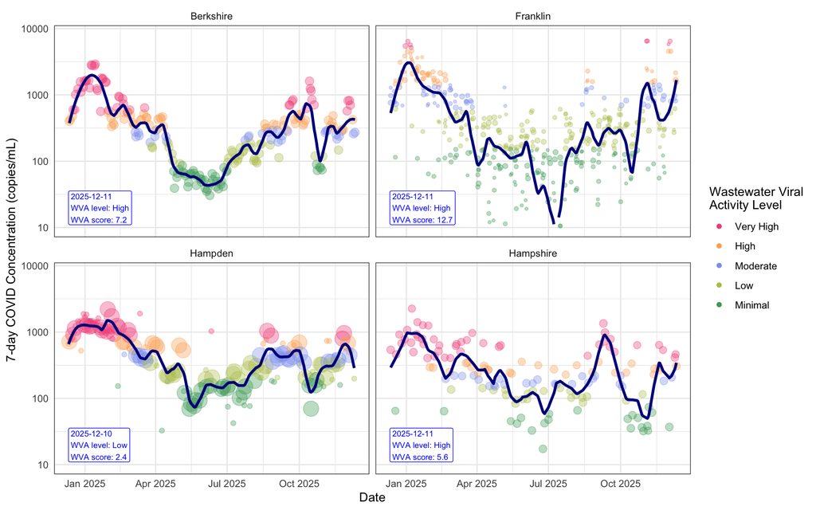

The above figure shows county-level wastewater COVID concentration and Wastewater Viral Activity level (WVA) for 9 sewer systems in Berkshire County (Pittsfield); Hampden County (S. Hadley, Springfield); Hampshire County (Amherst, Northampton), and Franklin County (Greenfield, Montague, S. Deerfield, Sunderland). WVA levels are relative to the previous 12 months of data. Blue annotations show the date of most recent report and the current WVA level.

Individual System Concentration and Wastewater Viral Activity Level

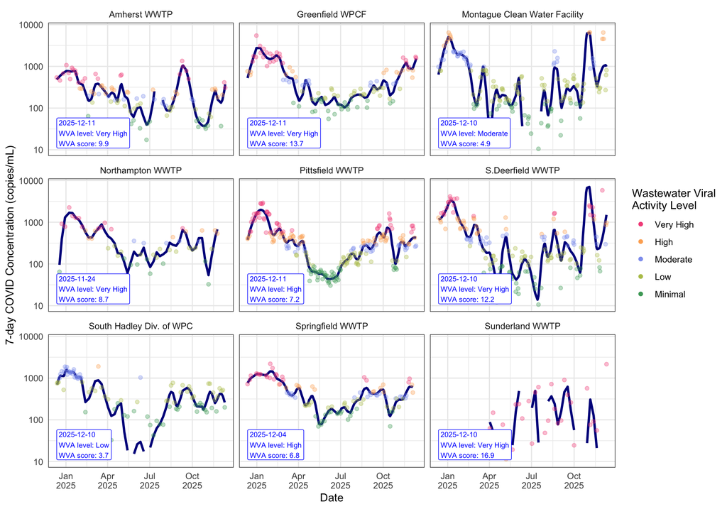

The above figure shows reported concentration data and Wastewater Viral Activity level (WVA) from 9 individual sewer systems in Berkshire, Hampden, Hampshire, and Franklin counties. WVA levels are relative to the previous 12 months of data. Blue annotations show the date of most recent report and the current WVA level.

**Technical Notes**  
• Wastewater Viral Activity levels are based on the CDC methodology linked below, with two differences:  
(1) use of weighted statistics (median and standard deviation) to calculate thresholds, with population served and reporting interval as weights; and  
(2) The baseline is updated each time the WVA is calculated, rather than every 6 months.  
• The WVA is relative to the previous 12 months of data and is calculated independently for each panel. Because of this, WVA thresholds may be different across panels. The y-axis (copies/mL) is fixed, but the WVA levels are relative.  
• The trend line is a smoothed conditional mean, specifically a Locally Estimated Scatterplot Smoother (or LOESS).  
• All analysis and visualization is performed in R. Data and scripts are accessible in the github respository here: https://github.com/raughter/western-mass-covid.

**Data Sources**  
• CDC methodology: https://www.cdc.gov/nwss/about-data.html#data-method  
• Wastewater data access: https://www.mass.gov/info-details/wastewater-surveillance-reporting  
• Population weights are from various sources (EPA estimates whenever available).  
**If you have the means, you can buy me a coffee here** https://ko-fi.com/raughter.  
**You can find my writing here** https://cultureofhomecoming.substack.com/  
**Stay safe, y’all <3**